# Housing Price Prediction

Ryan Sosinski, Naveen Kumar Reddy Bandagunda, Anand Surendran Nair, Damon Nicholas

2/25/2022

### Introduction:

With the housing market’s rapid appreciation in value the last few years, our group found this topic to be an interesting subject. With startups such as Opendoor creating an I-buy market, and other companies such as Redfin and Zillow chasing after them in terms of I-buy, data in the housing market is ever expanding. I-buy is the ability to sell a property on one of these businesses phone applications within seconds without the need of a realtor. To make this a reality, data analysis is needed to take several attributes and determine a fair market value offer, as a low offer will get ignored and an offer too high will hurt the business bad in profitability margins. Last year, it was also shown how little room for error data analysis is in the I-buy when Zillow temporarily exited the market due to their algorithm being unsuccessful and them losing a lot of money in that market. As a result, we think the ability to use attributes to determine housing prices is going to be an ever expanding skill needed in the real world today. When coming across the Dataset in Kaggle, we quickly determined this would be a good dataset to work with.

This dataset is related to housing prices, and lists other attributes such as area, bedrooms, ect. There are 13 attributes total in this dataset. In total, the following attributes in this dataset are: Price, area, bedrooms, bathrooms, stories, mainroad, guestroom, basement, hotwaterheating, airconditioning, parking, prefarea, and furningstatus. Price is the housing price, and it is a numeric value. Area is the area of the property and it is a numeric value. Bedrooms is how many bedrooms are included in the property and it is a numeric value. Bathrooms is how many bathrooms are included in the property and it is a numeric value. Stories is how many levels are included in the property and it is a numeric value. Mainroad is whether the property is on a mainroad and that is a yes/no value. Guestroom is whether or not the property includes a guestroom and that is a yes/no value. Basement is whether or not the property includes a basement and that is a yes/no value. Hotwaterheating is whether the property currently has hot water and that is a yes/no value. Airconditioning is whether or not the property contains airconditioning and that is a yes/no value. Parking is how many parking spaces the property has and it is a numeric value. Prefarea is whether the property is in a preferred area and it is a yes/no value. Furnishingstatus is whether the property is furnished and it is a value of furnished/semi-furnished/unfurnished.

#### Data source:

https://www.kaggle.com/yasserh/housing-prices-dataset

```r
#Housing <- read.csv("housing.csv")
getwd()
```

```
## [1] "C:/Users/DN/Downloads"
```

```r
Housing <- read.csv("C:\\Users\\DN\\Downloads\\housing.csv")
str(Housing)
```

```
## 'data.frame':    545 obs. of  13 variables:
##  $ price           : int  13300000 12250000 12250000 12215000 11410000 10850000 10150000 10150000 9870000 9800000 ...
##  $ area            : int  7420 8960 9960 7500 7420 7500 8580 16200 8100 5750 ...
##  $ bedrooms        : int  4 4 3 4 4 3 4 5 4 3 ...
##  $ bathrooms       : int  2 4 2 2 1 3 3 3 1 2 ...
##  $ stories         : int  3 4 2 2 2 1 4 2 2 4 ...
##  $ mainroad        : chr  "yes" "yes" "yes" "yes" ...
##  $ guestroom       : chr  "no" "no" "no" "no" ...
##  $ basement        : chr  "no" "no" "yes" "yes" ...
##  $ hotwaterheating : chr  "no" "no" "no" "no" ...
##  $ airconditioning : chr  "yes" "yes" "no" "yes" ...
##  $ parking         : int  2 3 2 3 2 2 2 0 2 1 ...
##  $ prefarea        : chr  "yes" "no" "yes" "yes" ...
##  $ furnishingstatus: chr  "furnished" "furnished" "semi-furnished" "furnished" ...
```

#### Basic Exploratory Data Analysis:

```r
housing <- Housing
housing$parking <- as.factor(housing$parking)
attach(housing)

library(tidyverse)
library(patchwork)
```

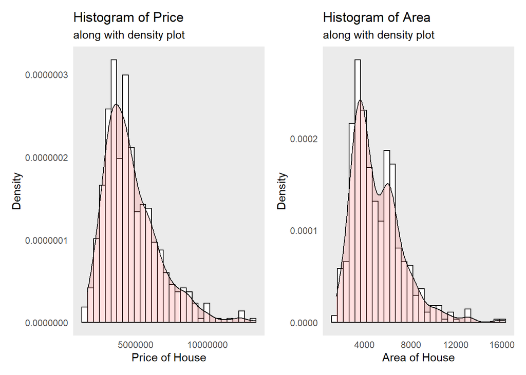

```r
plot1 <- ggplot(housing, aes(x=price)) +
    geom_histogram(aes(y=..density..),color="black", fill="white") +
    geom_density(alpha=.2, fill="#FF6666") +
    labs(title = "Histogram of Price",
         subtitle = "along with density plot") +
    theme(element_blank()) +
    ylab(label = "Density") +
    xlab(label = "Price of House") +
    scale_y_continuous(labels = function(x) format(x, scientific = FALSE)) +
    scale_x_continuous(labels = function(x) format(x, scientific = FALSE))


plot2 <- ggplot(housing, aes(x=area)) +
    geom_histogram(aes(y=..density..),color="black", fill="white") +
    geom_density(alpha=.2, fill="#FF6666") +
    labs(title = "Histogram of Area",
         subtitle = "along with density plot") +
    theme(element_blank()) +
    ylab(label = "Density") +
    xlab(label = "Area of House") +
    scale_y_continuous(labels = function(x) format(x, scientific = FALSE)) +
    scale_x_continuous(labels = function(x) format(x, scientific = FALSE))


plot3 <- housing %>%
  ggplot(aes(x=area,y=price)) +
  geom_point() +
  geom_smooth(method = lm) +
  scale_y_continuous(labels = function(x) format(x, scientific = FALSE))+
  scale_x_continuous(labels = function(x) format(x, scientific = FALSE)) +
  labs(title = "Scatter Plot of Price vs Area",
       subtitle = "along with regression line") +
  ylab(label = "Price") +
  xlab(label = "Area")

plot4 <- housing %>%
  ggplot(aes(x=mainroad,y=price, fill=mainroad)) +
  geom_boxplot() + geom_jitter(width=0.1,alpha=0.2) +
  scale_y_continuous(labels = function(x) format(x, scientific = FALSE)) +
  labs(title = "Box Plot of Price by Main Road") +
  ylab(label = "Price") +
  xlab(label = "Main Road")+
  theme(axis.ticks.x = element_blank(),
        axis.text.x = element_blank())


plot5 <- housing %>%
  ggplot(aes(x=guestroom,y=price, fill=guestroom)) +
  geom_boxplot() + geom_jitter(width=0.1,alpha=0.2) +
  scale_y_continuous(labels = function(x) format(x, scientific = FALSE)) +
  labs(title = "Box Plot of Price by Guest Room") +
  ylab(label = "Price") +
  xlab(label = "Guest Room")+
  theme(axis.ticks.x = element_blank(),
        axis.text.x = element_blank())

plot6 <- housing %>%
  ggplot(aes(x=basement,y=price, fill=basement)) +
  geom_boxplot() + geom_jitter(width=0.1,alpha=0.2) +
  scale_y_continuous(labels = function(x) format(x, scientific = FALSE)) +
  labs(title = "Box Plot of Price by Basement") +
  ylab(label = "Price") +
  xlab(label = "Basement")+
  theme(axis.ticks.x = element_blank(),
        axis.text.x = element_blank())

plot7 <- housing %>%
  ggplot(aes(x=hotwaterheating,y=price, fill=hotwaterheating)) +
  geom_boxplot() + geom_jitter(width=0.1,alpha=0.2) +
  scale_y_continuous(labels = function(x) format(x, scientific = FALSE)) +
  labs(title = "Box Plot of Price by Hot Water Heating") +
  ylab(label = "Price") +
  xlab(label = "Hot Water Heating")+
  theme(axis.ticks.x = element_blank(),
        axis.text.x = element_blank())


plot8 <- housing %>%
  ggplot(aes(x=airconditioning,y=price, fill=airconditioning)) +
  geom_boxplot() + geom_jitter(width=0.1,alpha=0.2) +
  scale_y_continuous(labels = function(x) format(x, scientific = FALSE)) +
  labs(title = "Box Plot of Price by Air Conditioning") +
  ylab(label = "Price") +
  xlab(label = "Air Conditioning")+
  theme(axis.ticks.x = element_blank(),
        axis.text.x = element_blank())


plot9 <- housing %>%
  ggplot(aes(x=furnishingstatus,y=price, fill=furnishingstatus)) +
  geom_boxplot() + geom_jitter(width=0.1,alpha=0.2) +
  scale_y_continuous(labels = function(x) format(x, scientific = FALSE)) +
  labs(title = "Box Plot of Price by Furnishing Status") +
  ylab(label = "Price") +
  xlab(label = "Furnishing Status")+
  theme(axis.ticks.x = element_blank(),
        axis.text.x = element_blank())

plot10 <- housing %>%
  ggplot(aes(x=prefarea,y=price, fill=prefarea)) +
  geom_boxplot() + geom_jitter(width=0.1,alpha=0.2) +
  scale_y_continuous(labels = function(x) format(x, scientific = FALSE)) +
  labs(title = "Box Plot of Price by Pref Area") +
  ylab(label = "Price") +
  xlab(label = "Pref Area")+
  theme(axis.ticks.x = element_blank(),
        axis.text.x = element_blank())

plot11 <- housing %>%
  ggplot(aes(x=parking,y=price)) +
  geom_col() +
  scale_y_continuous(labels = function(x) format(x, scientific = FALSE)) +
  labs(title = "Bar Chart of Price by Parking") +
  ylab(label = "Price") +
  xlab(label = "Parking")


plot1+plot2
```

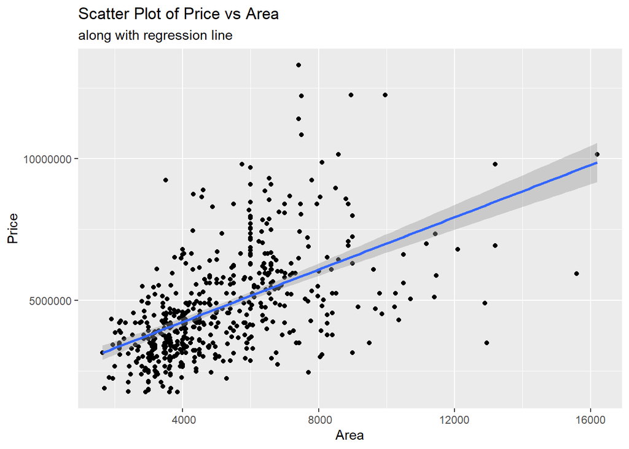

```r
plot3
```

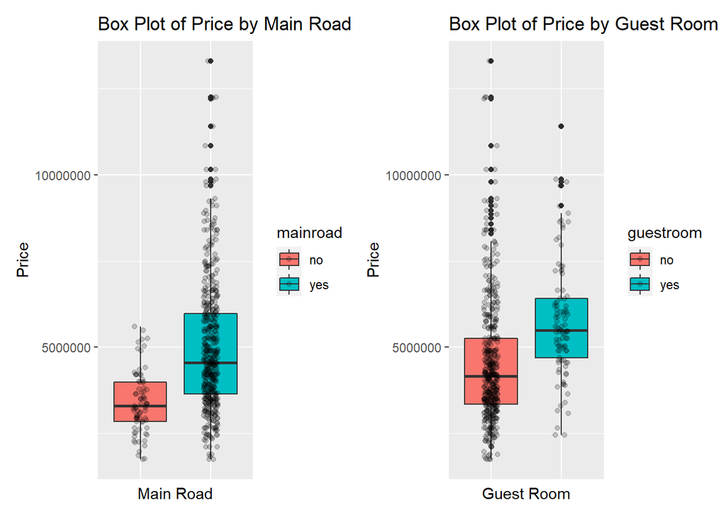

```r
plot4+plot5
```

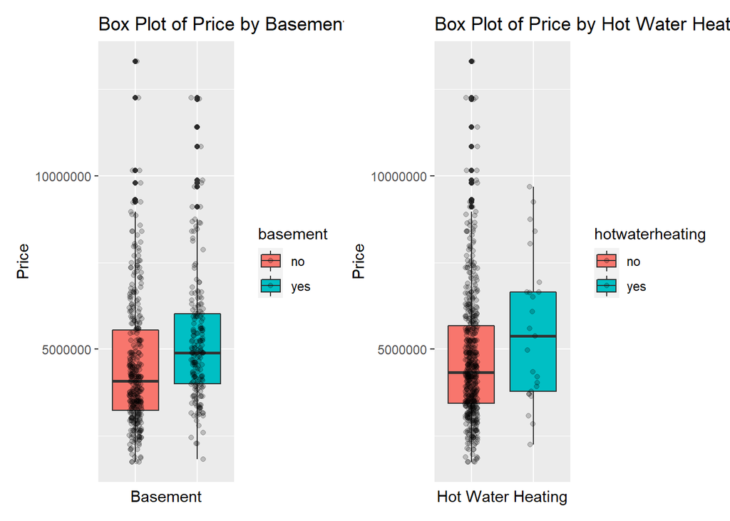

```r
plot6+plot7
```

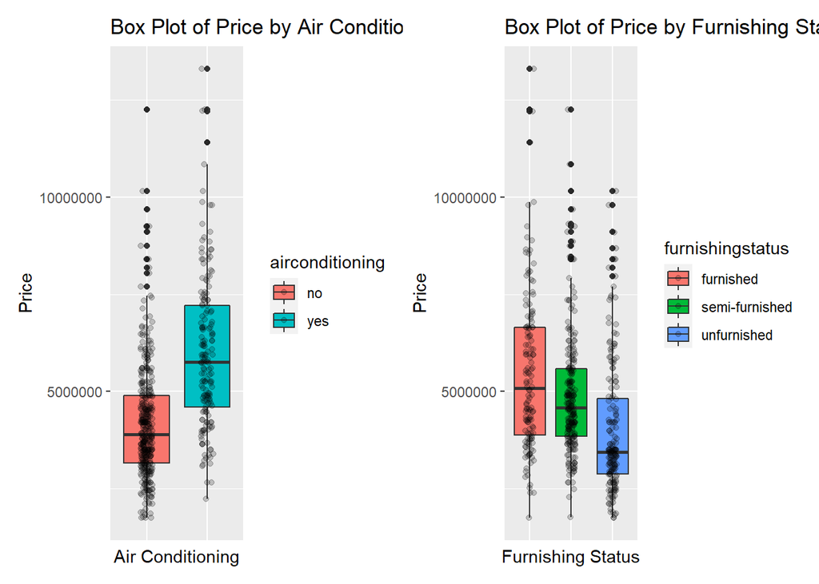

```r
plot8+plot9
```

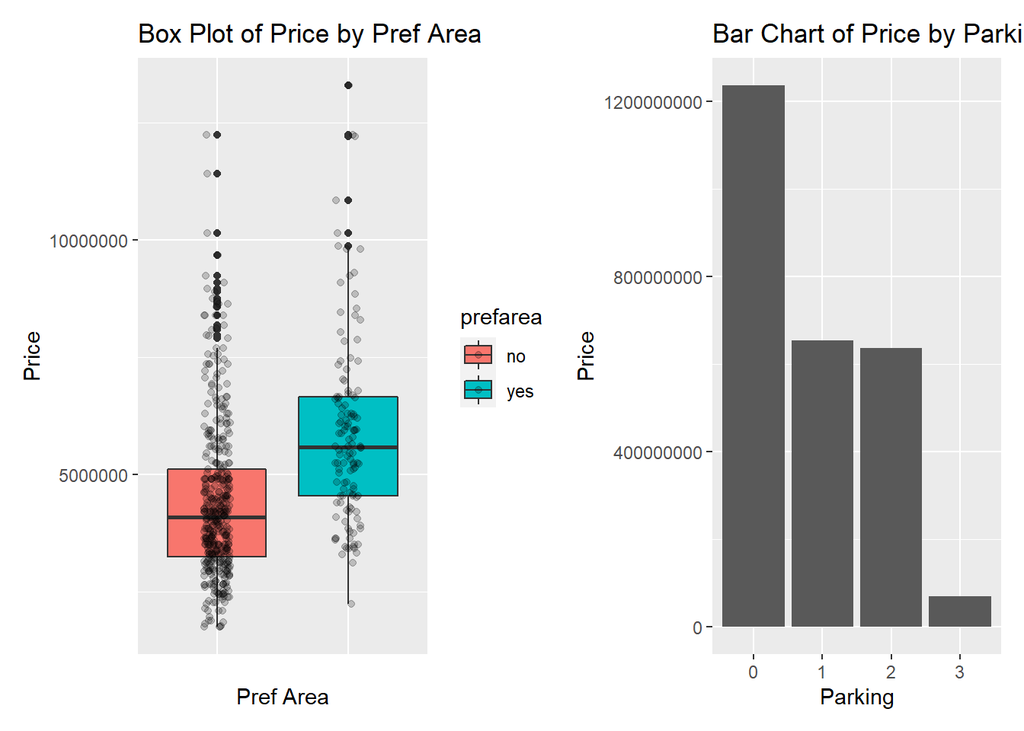

```r
plot10+plot11
```

```r
#source("http://www.sthda.com/upload/rquery_cormat.r")
#rquery.cormat(Housing)
```

####Takeaways For our exploratory data analysis we used GGplot to use a various number of visualizations to see if certain variables had a relationship with price.

GGplot

-Histogram of Prices with density plot. As we can see with this histogram, prices are not normally distributed. Prices skew to the lower costs, and the outliers ten to be the ultra-expensive houses.

-Scatter plot price vs area, with regression line. There appears to be a linear relationship between area and price. The linear regression of this dataset will be addressed in the linear regression portion as well.

-Box plot of price in regards to location on main road. Properties on a main road have a higher mean and a higher variance than houses not on a main road. If we were to interpret the variance, the prediction would be that non main road houses tend to be suburban projects of similarly priced properties.

-Box plot of price by whether or not it has a guest room. Unsurprisingly, properties with guestrooms tend to have more value. Although in regards to outliers, the most expensive properties do not have a guest room.

-Box plot of price by whether or not it has basement. Properties with basements have a higher mean value. Similar to the guestrooms though, the outliers of no basement are the highest property values in the dataset.

-Box plot of price by whether or not it has hot water heating. The mean of properties with hot water heating are higher. The most valuable properties (outliers) do not have hot water heating.

-Box plot of price by whether or not it has air conditioning. Air-conditioned properties have a higher mean value.

-Box plot of price by furnishing status. Unfurnished properties have the lowest mean in price. Semi furnished have the middle mean in price. Furnished properties have the highest mean in price. This is as expected.

-Box plot of price by whether or not the property is in a preferred area. Preferred area properties have a higher mean price, unsurprisingly.

### Model Building

```r
attach(Housing)
head(Housing)
```

```
##      price area bedrooms bathrooms stories mainroad guestroom basement
## 1 13300000 7420        4         2       3      yes        no       no
## 2 12250000 8960        4         4       4      yes        no       no
## 3 12250000 9960        3         2       2      yes        no      yes
## 4 12215000 7500        4         2       2      yes        no      yes
## 5 11410000 7420        4         1       2      yes       yes      yes
## 6 10850000 7500        3         3       1      yes        no      yes
##   hotwaterheating airconditioning parking prefarea furnishingstatus
## 1              no             yes       2      yes        furnished
## 2              no             yes       3       no        furnished
## 3              no              no       2      yes   semi-furnished
## 4              no             yes       3      yes        furnished
## 5              no             yes       2       no        furnished
## 6              no             yes       2      yes   semi-furnished
```

```r
n<-dim(Housing)[1]

split<-sample(nrow(Housing),nrow(Housing)*0.80)

train_Housing<-Housing[split,]
test_Housing<-Housing[-split,]
```

#### 1. Full linear regression model

```r
attach(train_Housing)
fit.lm<-lm(price~.,data = train_Housing)
summary(fit.lm)
```

```
##
## Call:
## lm(formula = price ~ ., data = train_Housing)
##
## Residuals:
##      Min       1Q   Median       3Q      Max
## -2694852  -667562   -76650   472219  4591564
##
## Coefficients:
##                                  Estimate Std. Error t value Pr(>|t|)
## (Intercept)                    -271410.35  296786.16  -0.914  0.36098
## area                               240.20      26.55   9.046  < 2e-16 ***
## bedrooms                        150160.82   79968.60   1.878  0.06111 .
## bathrooms                      1054189.08  114688.82   9.192  < 2e-16 ***
## stories                         427447.20   72394.25   5.904 7.28e-09 ***
## mainroadyes                     509458.47  160616.79   3.172  0.00163 **
## guestroomyes                    369680.64  147244.35   2.511  0.01242 *
## basementyes                     405904.83  125198.97   3.242  0.00128 **
## hotwaterheatingyes             1026686.11  241670.27   4.248 2.65e-05 ***
## airconditioningyes              905570.00  121154.53   7.475 4.51e-13 ***
## parking                         303605.33   66043.58   4.597 5.67e-06 ***
## prefareayes                     625930.52  130005.39   4.815 2.06e-06 ***
## furnishingstatussemi-furnished   22865.54  131459.65   0.174  0.86200
## furnishingstatusunfurnished    -341281.31  141928.89  -2.405  0.01662 *
## ---
## Signif. codes:  0 '***' 0.001 '**' 0.01 '*' 0.05 '.' 0.1 ' ' 1
##
## Residual standard error: 1079000 on 422 degrees of freedom
## Multiple R-squared:  0.6903, Adjusted R-squared:  0.6808
## F-statistic: 72.36 on 13 and 422 DF,  p-value: < 2.2e-16
```

```r
pred0<-predict(fit.lm, newdata = test_Housing)
MSE_full_model<-mean((test_Housing$price-pred0)^2)


#lets do the variable selection methods to see which variables are the best

#trying AIC stepwise model selection
```

#### 2. AIC stepwise regression model

```r
aic.model<-lm(price~.-guestroom, data = train_Housing)
summary(aic.model)
```

```
##
## Call:
## lm(formula = price ~ . - guestroom, data = train_Housing)
##
## Residuals:
##      Min       1Q   Median       3Q      Max
## -2847156  -642423   -32554   487475  4808666
##
## Coefficients:
##                                  Estimate Std. Error t value Pr(>|t|)
## (Intercept)                    -294548.56  298496.84  -0.987  0.32432
## area                               245.32      26.64   9.208  < 2e-16 ***
## bedrooms                        146076.53   80451.69   1.816  0.07012 .
## bathrooms                      1073493.18  115145.90   9.323  < 2e-16 ***
## stories                         430828.51   72834.05   5.915 6.85e-09 ***
## mainroadyes                     527917.33  161451.11   3.270  0.00116 **
## basementyes                     513475.49  118374.62   4.338 1.80e-05 ***
## hotwaterheatingyes             1025061.43  243179.67   4.215 3.05e-05 ***
## airconditioningyes              927871.86  121583.55   7.632 1.55e-13 ***
## parking                         293448.55   66331.51   4.424 1.23e-05 ***
## prefareayes                     628476.76  130813.85   4.804 2.16e-06 ***
## furnishingstatussemi-furnished   12348.52  132214.01   0.093  0.92563
## furnishingstatusunfurnished    -355104.04  142708.35  -2.488  0.01322 *
## ---
## Signif. codes:  0 '***' 0.001 '**' 0.01 '*' 0.05 '.' 0.1 ' ' 1
##
## Residual standard error: 1086000 on 423 degrees of freedom
## Multiple R-squared:  0.6857, Adjusted R-squared:  0.6768
## F-statistic:  76.9 on 12 and 423 DF,  p-value: < 2.2e-16
```

```r
pred<-predict(aic.model, newdata = test_Housing)
MSE_AIC_model<-mean((test_Housing$price-pred)^2)
```

#### 3. BIC regression model

```r
bic.model<-lm(price~.-guestroom-bedrooms-mainroad, data = train_Housing)
summary(bic.model)
```

```
##
## Call:
## lm(formula = price ~ . - guestroom - bedrooms - mainroad, data = train_Housing)
##
## Residuals:
##      Min       1Q   Median       3Q      Max
## -2876288  -661312   -30424   504657  4898296
##
## Coefficients:
##                                  Estimate Std. Error t value Pr(>|t|)
## (Intercept)                     330521.92  227848.90   1.451  0.14762
## area                               264.99      26.38  10.047  < 2e-16 ***
## bathrooms                      1089862.67  114245.36   9.540  < 2e-16 ***
## stories                         492000.66   69139.48   7.116 4.75e-12 ***
## basementyes                     548495.68  118467.47   4.630 4.87e-06 ***
## hotwaterheatingyes             1040601.08  246091.30   4.229 2.88e-05 ***
## airconditioningyes              939894.47  123025.72   7.640 1.46e-13 ***
## parking                         326338.27   66493.73   4.908 1.31e-06 ***
## prefareayes                     677852.70  131359.35   5.160 3.79e-07 ***
## furnishingstatussemi-furnished   -4612.38  133647.31  -0.035  0.97249
## furnishingstatusunfurnished    -400942.59  143803.35  -2.788  0.00554 **
## ---
## Signif. codes:  0 '***' 0.001 '**' 0.01 '*' 0.05 '.' 0.1 ' ' 1
##
## Residual standard error: 1100000 on 425 degrees of freedom
## Multiple R-squared:  0.6763, Adjusted R-squared:  0.6687
## F-statistic: 88.81 on 10 and 425 DF,  p-value: < 2.2e-16
```

```r
pred1<-predict(bic.model, newdata = test_Housing)
MSE_BIC_model<-mean((test_Housing$price-pred1)^2)
```

Lets try building the model using Regression trees

#### 4.Regression tree

```r
fit.tree<-rpart(formula=price~., data = train_Housing)
```

```r
plotcp(fit.tree)
printcp(fit.tree)
```

[output not shown]

Plot of the tree:

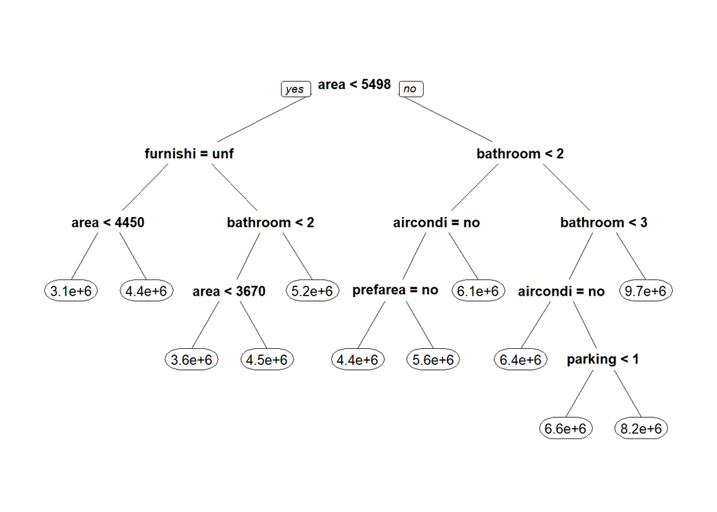

```r
prp(fit.tree)
```

```r
test_pred <- predict(fit.tree, test_Housing)
MSE.tree<-mean((test_Housing$price-test_pred)^2)
```

Plot of the tree after its pruned:

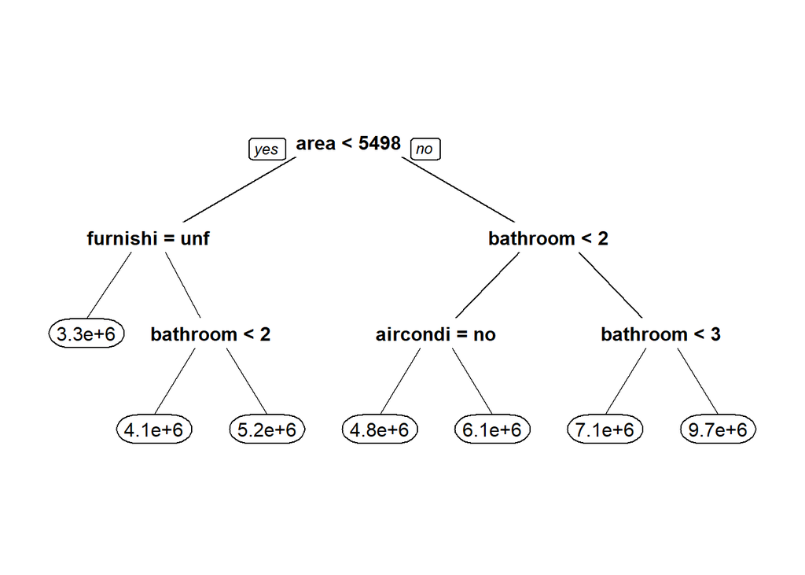

```r
fit.tree.pruned<-prune(fit.tree, cp=0.022852)
prp(fit.tree.pruned)
```

```r
test_pred1 <- predict(fit.tree.pruned, test_Housing)
MSE.tree_pruned<-mean((test_Housing$price-test_pred1)^2)
```

Tree before pruning performed better than the tree after pruning however, the MSE of the model is not better than the basic full linear regression model.

```r
data.frame(MSE_full_model, MSE_AIC_model, MSE_BIC_model, MSE.tree, MSE.tree_pruned)
```

```
##   MSE_full_model MSE_AIC_model MSE_BIC_model     MSE.tree MSE.tree_pruned
## 1   1.088629e+12   1.07407e+12  1.044249e+12 1.354155e+12    1.513601e+12
```

New Functions

Broom Package

Broom is an output cleaning function developed to try and resolve the issue of tidy inputs not generating tidy outputs in R, which makes it more difficult on the user to efficiently compare and combine results from multiple models. This was helpful in our situation because we were comparing the outputs of two similar models, as considering the package’s effect on the “Quality of Life” for using R as a statistical tool. Looking at the below outputs, each tibble quickly summarizes the AIC and BIC models and allows for quicker and easier comparison when distinguishing it from the standard model’s output. The glance function was used for this example, but in our research, Broom users also commonly use the tidy and augment functions to improve standard R outputs.

```r
glance(aic.model)
```

```
## # A tibble: 1 x 12
##   r.squared adj.r.squared    sigma statistic  p.value    df logLik    AIC    BIC
##       <dbl>         <dbl>    <dbl>     <dbl>    <dbl> <dbl>  <dbl>  <dbl>  <dbl>
## 1     0.686         0.677 1086111.      76.9 2.86e-98    12 -6672. 13371. 13428.
## # ... with 3 more variables: deviance <dbl>, df.residual <int>, nobs <int>
```

```r
glance(bic.model)
```

```
## # A tibble: 1 x 12
##   r.squared adj.r.squared    sigma statistic  p.value    df logLik    AIC    BIC
##       <dbl>         <dbl>    <dbl>     <dbl>    <dbl> <dbl>  <dbl>  <dbl>  <dbl>
## 1     0.676         0.669 1099558.      88.8 1.48e-97    10 -6678. 13380. 13429.
## # ... with 3 more variables: deviance <dbl>, df.residual <int>, nobs <int>
```

Data Explorer package

While searching around for new R packages to explorer, one that we noticed a lot of appreciation for was Data Explorer. It is a Powerful package that runs a report for many aspects of data exploration that could be missed. Included in this report are counts of rows, columns, missing observersation (in case the data isn’t cleaned). There are histograms, bar charts, QQ plots, correlation analysis between attributes, principal and component analysis for variance. Overall, this package is one that we plan to use in the future. It gave us analysis of several aspects that we may have missed in our freestyle exploratory analysis.

```r
create_report(Housing)
```

```
##
##
## processing file: report.rmd
```

[output not shown]

[output not shown]

[output not shown]

[output not shown]

[output not shown]

[output not shown]

[output not shown]

[output not shown]

```
## output file: C:/Users/DN/Downloads/report.knit.md
```

[output not shown]

```
##
## Output created: report.html
```